# Intro to Data Science - HW 5

##### Copyright 2021, Jeffrey Stanton, Jeffrey Saltz, and Jasmina Tacheva

```r
# Enter your name here:Pranav Sharma
```

### Attribution statement: (choose only one and delete the rest)

```r
# 1. I did this homework by myself, with help from the book and the professor.
```

```r
#install.packages("ggplot2")
library(ggplot2)
```

## Including Plots

1. Run these two lines of code. What happens? How do you actually “invoke” the plot (i.e., how do you get it to draw in the plot window)?

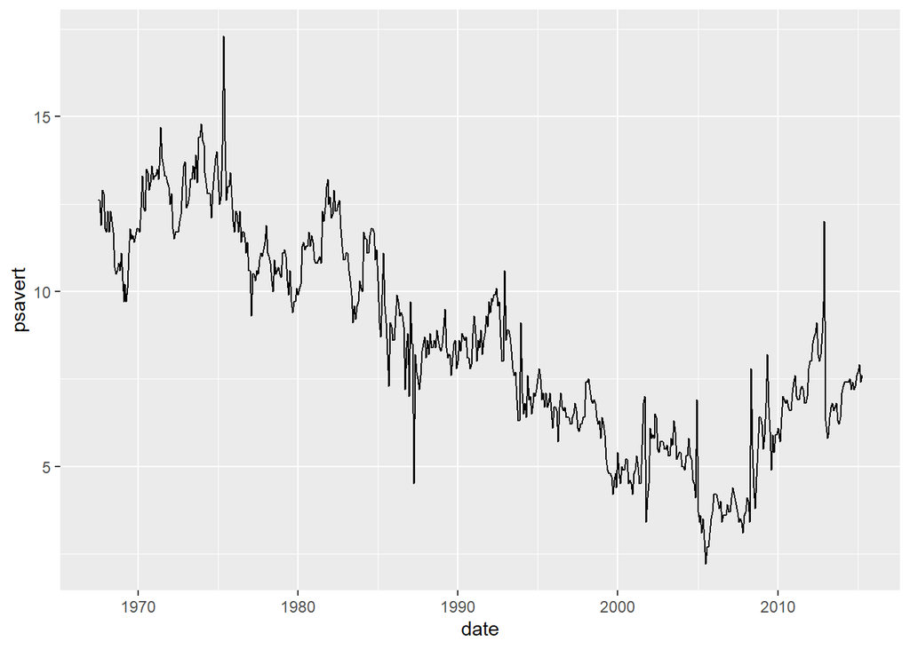

```r
myPlot <- ggplot(economics, aes(x=date))
myPlot <- myPlot + geom_line(aes(y=psavert))
myPlot
```

2. Run help(“economics”) to find out the meaning of the psavert variable.

```r
help("economics")
```

```
## starting httpd help server ... done
```

```r
#psavert  means personal saving rate
# Personal saving as a percentage of disposable personal income (DPI), frequently referred to as "the personal saving rate," is calculated as the ratio of personal saving to DPI.
```

3. Examine the plot to estimate when the personal savings rate reached its maximum value. Also examine the plot to estimate when the personal savings rate reached its minimum value.

```r
# the plot reached a maximum value approximately between 1970 and 1980.I am estimating it was in 1975 . The plot minimum where personal saving rate goes to minimum is also approximately between 2000 and 2010. I estimate it is year 2005
```

4. Use which.max( ) and which.min( ) to verify your guesses from problem 3.

```r
economics[which.max(economics$psavert),]$date
```

```
## [1] "1975-05-01"
```

```r
economics[which.min(economics$psavert),]$date
```

```
## [1] "2005-07-01"
```

5. Change the color of the plot line to green. Hint: Changing a line to a constant color happens in the specification of the geometry.

```r
myPlot <- myPlot +  geom_line(aes(y=psavert),color='green')
```

6. Add a title to the plot with the ggtitle(“Put title here”) sub-command. The title “Personal Savings Rate: 1967-2014” would be a good choice.

[figure not shown]

```r
myPlot <- myPlot + ggtitle("Personal    Savings Rate:   1967-2014")
myPlot
```

7. Add another data series to your plot to show the variable uempmed as a red line.

```r
myPlot <- myPlot + geom_line(aes(y=uempmed),color = 'red')
```